# Introduction to Computational Social Sciences

Malo Jan & Luis Sattelmayer

January 19, 2026

# Course Introduction

## About us

- Malo Jan
  - 4th year PhD student at the CEE working on Climate politics, Party politics, Quantitative and computational methods
  - malo.jan@sciencespo.fr
  - https://malojan.github.io/website/
- Luis Sattelmayer
  - 4th year PhD student at the CEE working on Party Competition, Partisan Strategies, Immigration Politics, Quantitative and computational methods
  - luis.sattelmayer@sciencespo.fr
  - https://luissattelmayer.github.io/website/

## Goals of the course

- Introduction to Computational Social Sciences
- From data collection to analysis
- Mostly about text analysis
- Exposure to different methods, tools, and their applications
- Prerequisites: solid command of RStudio
- Goal is to provide a non-technical introduction, focus on *use cases*

## Outline of the course

| Day | Session 1 | Session 2 | Session 3 |
| --- | --- | --- | --- |
| 1 | Intro to CSS + Corpus selection | Web scraping in R | Coding session |
| 2 | Manipulating textual data | From text to numbers | Coding session |
| 3 | Supervised machine learning (SML) for text classification | SML in R | Coding session |
| 4 | Embeddings | Embeddings in R and Python | Coding session |
| 5 | Large language models (LLMs) | LLMs in Python & R | Open |

## Course material

- Slides and code will be available on the course’s [Github repository](https://github.com/luissattelmayer/intro-css/tree/main)
- If you are not familiar with Git and Github, have a look at this [tutorial](https://happygitwithr.com/)

# Computational Social Sciences

## What is CSS?

> Computational social science is an interdisciplinary field that advances theories of human behavior by applying computational techniques to large datasets from social media sites, the Internet, or other digitized archives such as administrative records. Edelmann et al. (2020)

[figure not shown]

[figure not shown]

- Computational Social Science (CSS) is an interdisciplinary field at the intersection of social sciences, computer science, and data science.

## More data, computing power and methods

CSS from two main developments :

- New and more data
  - Data on the web : digitization of text, historical archives, administrative records, open data
  - Data from the web : social media, websites
  - Unstructured data : text, images, videos, not produced by researchers
  - Collecting population rather than sample
- New methods and computing power
  - More powerful computers and hardware (mostly GPUs)
  - More powerful algorithms, methods, models, IA
  - Allows to train more complex models: advent of LLMs

## Developments in political science

- Early development of computational text analysis in the 2000’s in political science : convert text to numbers to perform statistical analysis
- But really booming over the last few years with advances in AI allowing to perform more complex analysis
- Even more recent developments :
  - Muiltilingual text analysis
  - Image, Video as data, *multimodal* analysis
  - Generative language models (LLMs)

## What are textual statistics?

- Capture *latent meaning* in text
  - Meaning can be discovered through the method (inductively – unsupervised)
  - Or we can use more deductive reasoning beforehand to nudge the method toward a specific underlying pattern of interest (supervised)
- This means that we are more or less informed about the *latent dimensionality(ies)* of our texts
- It is also a mathematization of language
  - written or not, there is no difference as long as the text is available in a form that is readable for computers

## Representing text-as-data

- Analyzing text-as-data involves transforming text into a numeric representation in order to use statistical models (clustering, scaling, topic models, supervised machine learning etc.)
- Featurization: extract numeric features from raw text
- Three main steps in text analysis:
  1. **Bag of words representation**
  2. **Static word embeddings**
  3. **Contextual embeddings from Large Language Models (LLMs)**

> The best method depends on the task

## Why use these methods?

- Counter issues of data availability
- Uncover patterns/dimensionalities in text that humans do not recognize as such
- Save time (*scalability* of methods)
- Albeit being a quantitative method, methods covered in this class are also useful for qualitative research
  - collecting documents, corpora
  - organizing and structuring data
  - uncovering patterns *inductively*

## Six principles for CSS (Grimmer, Roberts, and Stewart 2022)

1. Social science theories and substantive knowledge are essential for research design.
2. Text analysis does not replace humans – it augments them (see also Do, Ollion, and Shen (2024))
3. Building, refining, and testing social science theories requires iteration and cumulation.
4. Text analysis methods distill generalizations from language.
5. The best method depends on the task.
6. Validations are essential and depend on the theory and the task.

## Social group detection in party manifestos

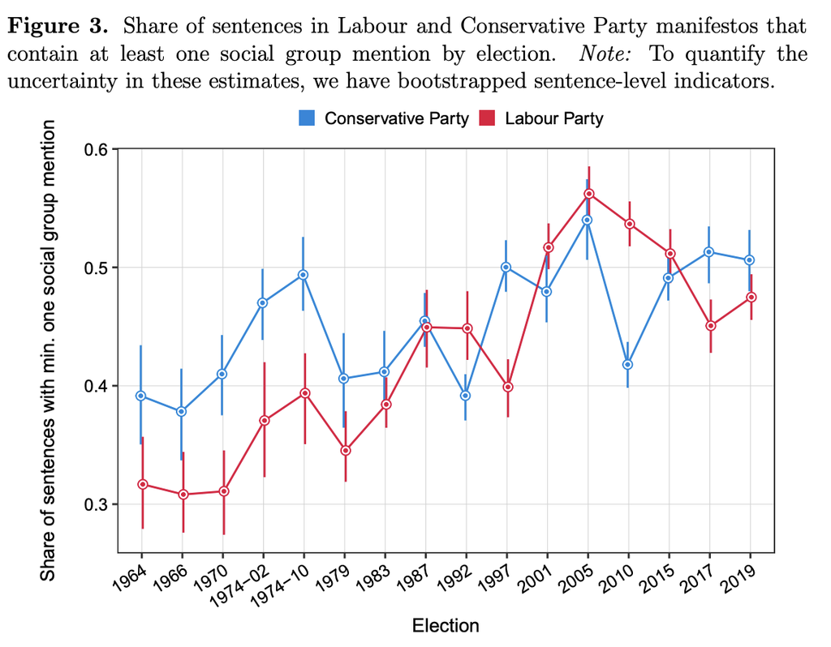

Licht and Sczepanksi (2024)

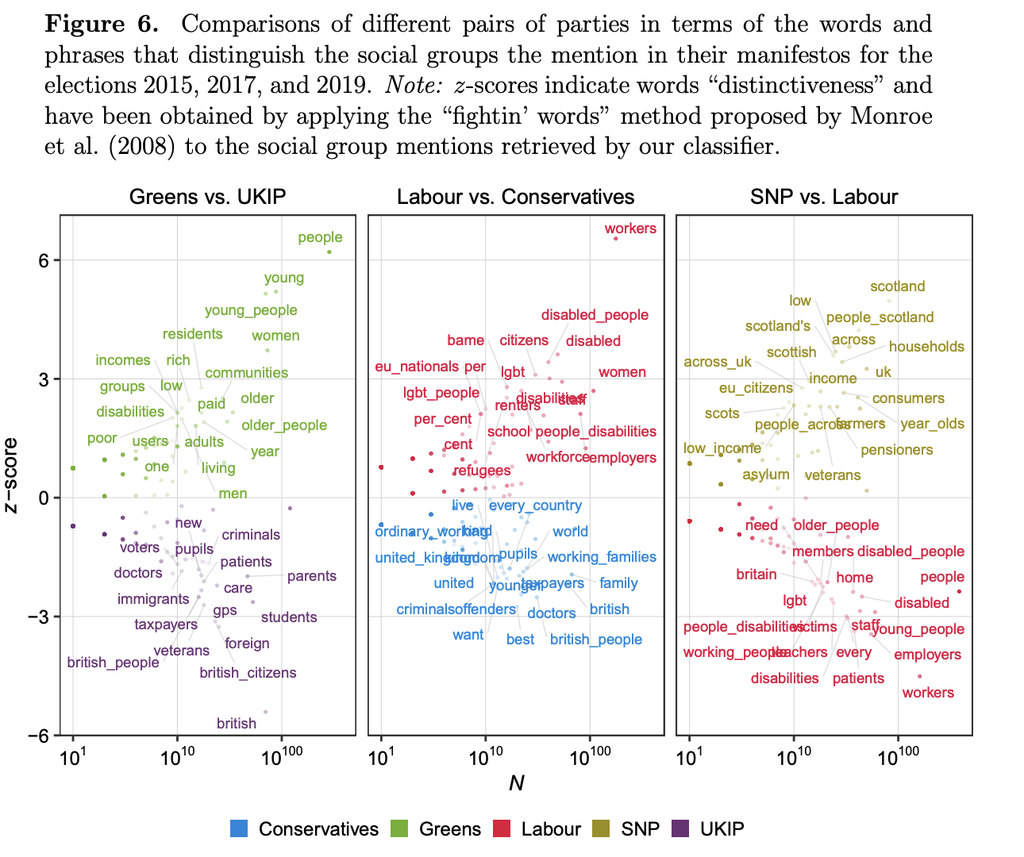

## The meaning of “class” in books

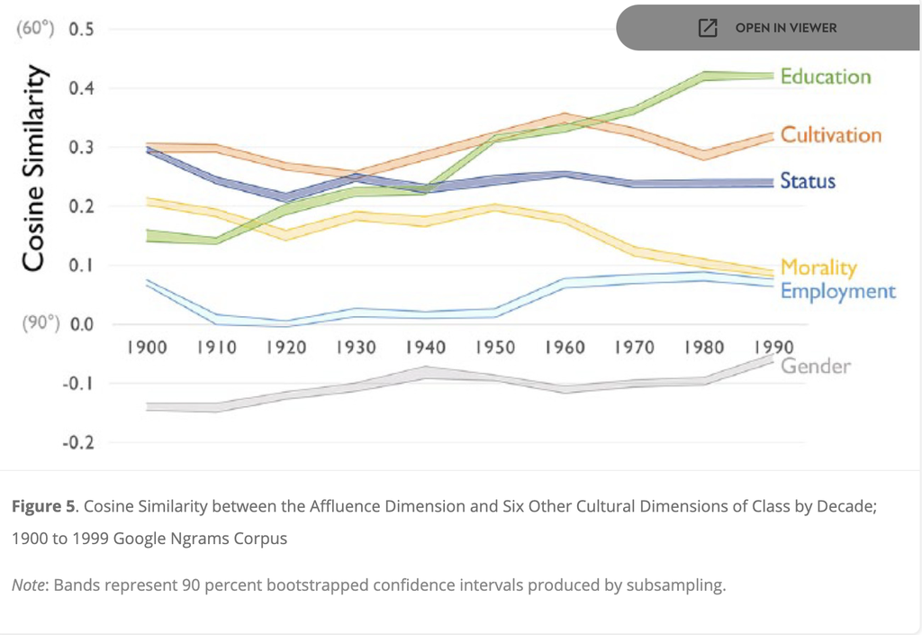

## Immigration stance over time in Germany

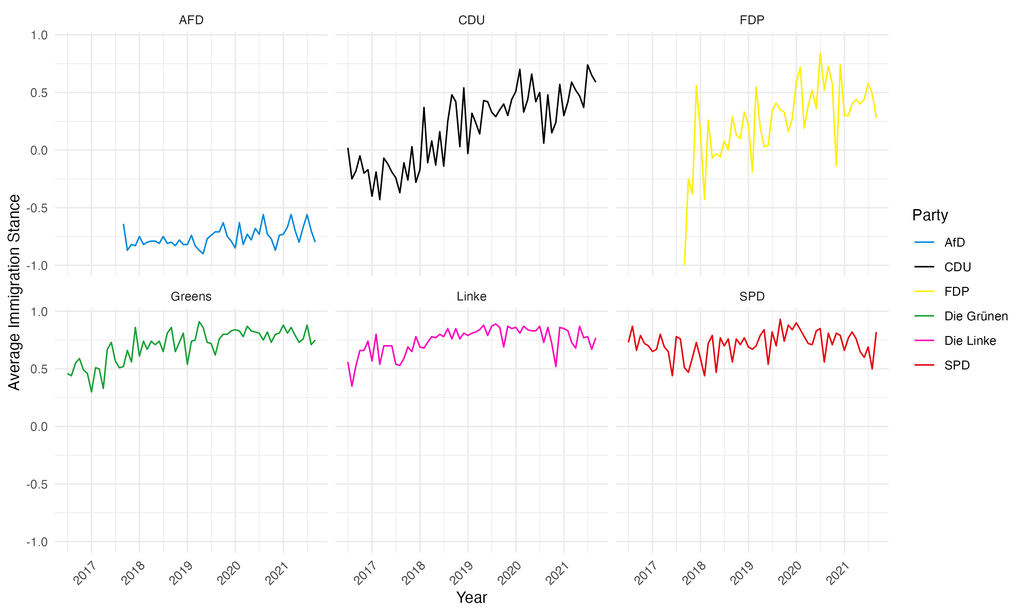

## Bonikowski, Luo, and Stuhler (2022) Measuring Populism

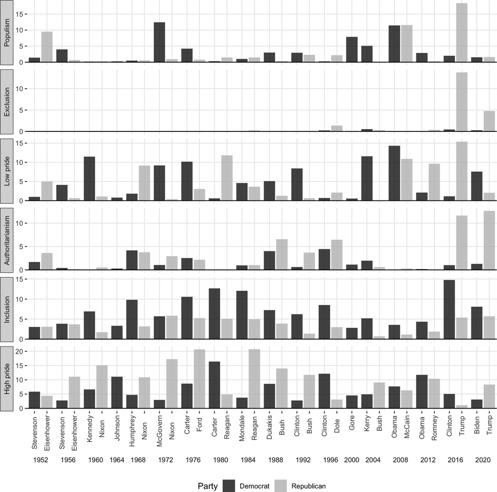

## References

Bonikowski, Bart, Yuchen Luo, and Oscar Stuhler. 2022. “Politics as Usual? Measuring Populism, Nationalism, and Authoritarianism in US Presidential Campaigns (1952–2020) with Neural Language Models.” *Sociological Methods & Research* 51 (4): 1721–87.

Do, Salomé, Étienne Ollion, and Rubing Shen. 2024. “The Augmented Social Scientist: Using Sequential Transfer Learning to Annotate Millions of Texts with Human-Level Accuracy.” *Sociological Methods & Research* 53 (3): 1167–1200.

Edelmann, Achim, Tom Wolff, Danielle Montagne, and Christopher A Bail. 2020. “Computational Social Science and Sociology.” *Annual Review of Sociology* 46 (1): 61–81.

Grimmer, Justin, Margaret E Roberts, and Brandon M Stewart. 2022. *Text as Data: A New Framework for Machine Learning and the Social Sciences*. Princeton University Press.

Licht, Hauke, and Ronja Sczepanksi. 2024. “Who Are They Talking about? Detecting Mentions of Social Groups in Political Texts with Supervised Learning.” ECONtribute Discussion Paper.